# Prob 5, CP 1

Daniyel Rocha

24 de agosto de 2017

```r
library(openintro, quietly = T)
library(tidyverse, quietly = T)
library(dplyr, quietly = T)
theme_set(theme_bw())
library(modelr, quietly = T)
library(broom, quietly = T)
library(GGally, quietly = T)
```

# Introdução

Para esta análise os dados que serão utilizados são referentes a encontros rápidos, também chamados de *“speed dating”*. Nesse tipo de encontro, diversas pessoas irão se conhecer, sendo cada par é sugerido por um sistema que foi alimentado com informações de cada participante e julga que aquele encontro deve acontecer. Após cada encontro, os participantes envolvidos deveriam preencher fichas avaliando a outra pessoa, com base em diversos critérios. Com isso, o conjunto de dados formado será analisado e perguntas envolvendo cada uma das variáveis foram elaboradas e serão respondidas neste relatório.

# Os dados

Diversas varíaveis compõem o conjuno de dados. As informações detalhadas sobre cada uma delas pode ser vista [aqui](https://github.com/nazareno/ciencia-de-dados-1/tree/master/5-regressao/speed-dating). De forma geral, iremos analisar as variáveis que refletem a opinião que uma pessoa teve sobre a outra durante o encontro - mas também iremos utilzar variáveis sobre as impressões que uma pessoa tem de si própria. Em um primeiro momento selecionaremos os dados, que depois serão filtrados de modo a responder as perguntas criadas.

```r
#selecionando os dados sem os NA's
speed_dating <- na.omit(read.csv("https://raw.githubusercontent.com/nazareno/ciencia-de-dados-1/master/5-regressao/speed-dating/speed-dating.csv"))
```

# Perguntas

## Primeira pergunta

- Para pessoas maiores de 30 anos, quanto a inteligência e ambição irão influenciar sobre o like para outra pessoa?

Com essa pergunta procuramos saber se pessoas consideradas mais maduras (se é que com 30 anos uma pessoa é madura) tendem a gostar mais de uma determinada pessoa, se também a considera mais inteligente e ambiciosa. Isso pode mostrar se esses aspectos influenciam no like, evidenciando que talvez as pessoas com essa idade procuram alguma estabilidade e essas variáveis caracterizariam alguém com o perfil que atenda um público mais ‘maduro’. Realizamos a filtragem dos dados para depois criarmos um modelo de regressão linear que possa mostrar o quanto que as variáveis escolhidas influenciam no like.

```r
p1_data <- speed_dating %>%
  filter(age > 30) %>%
  select(like,amb,intel)
```

Podemos observar o quanto as variáveis estão relacionadas utilizando a análise de correlação.

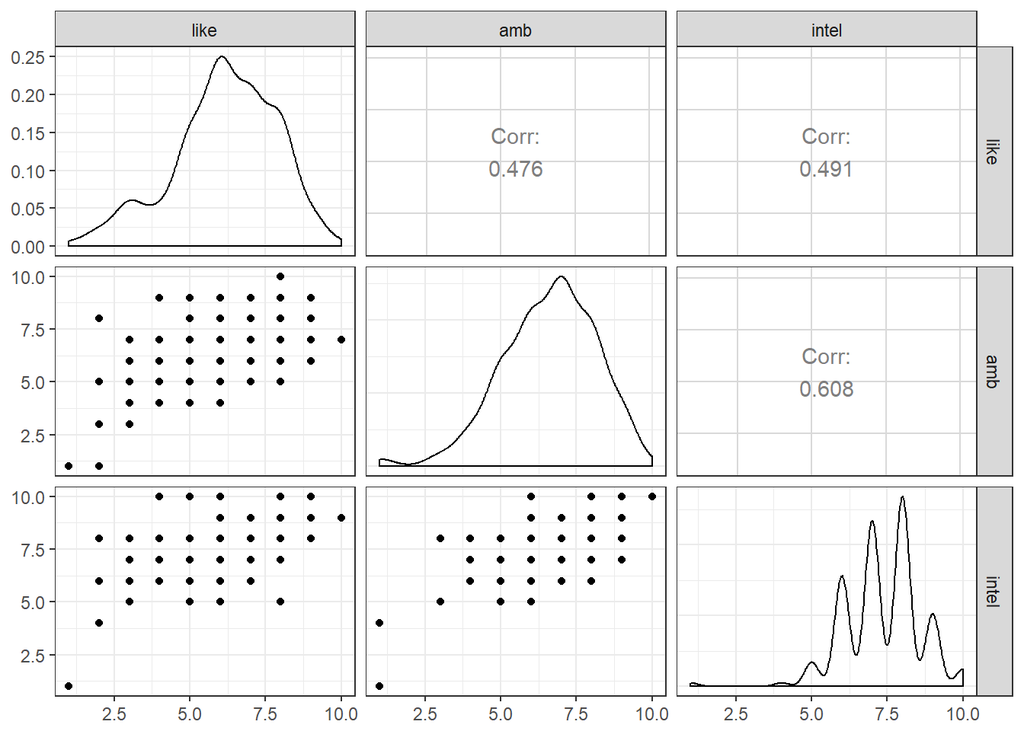

```r
p1_data %>%
  ggpairs()
```

Vemos que a correlação entre as variáveis está num meio-termo: não é uma correlação muito forte, mas também não muito fraca.  
Podemos definir nosso modelo de regressão, onde o like será nossa variável dependente das outras duas (inteligência e ambição).

```r
model_intel_amb <- lm(like ~ amb + intel, data = p1_data)
tidy(model_intel_amb, conf.int = TRUE)
```

```
##          term  estimate  std.error statistic      p.value   conf.low
## 1 (Intercept) 0.9773058 0.66003363  1.480691 0.1405731460 -0.3257794
## 2         amb 0.3067485 0.08949232  3.427651 0.0007666918  0.1300664
## 3       intel 0.4316758 0.11046074  3.907957 0.0001350265  0.2135964
##   conf.high
## 1 2.2803910
## 2 0.4834306
## 3 0.6497552
```

A tabela acima nos mostra os resultados do modelo gerado.  
A coluna **estimate** pode nos mostrar informações sobre a magnitude dos coeficientes: isso nos indica o quanto cada uma das variáveis independentes estão influenciando no like. Os valores descritos nessa coluna irão mostrar que a inteligência (0.43) tem um peso levemente maior na variável like, em comparação com a ambição (0.30). O **p-valor** irá nos mostrar o quanto as variáveis independentes do modelo são significantes para nossa variável like. Como o p-valor das duas é algo próximo a zero, podemos inferir que elas representam bem nosso modelo e a relação com a variável like. Podemos também observar que esses valores estão dentro dos intervalos de confiança, fortalecendo o que observamos sobre a significância e mostrando a relevância destes elementos.  
Vimos que nosso modelo pode mostrar quanto a inteligência e a ambição influencia no like. Mas o quanto do valor dos dados de like estão sendo explicados pelas duas variáveis?

```r
glance(model_intel_amb, conf.int = TRUE)
```

```
##   r.squared adj.r.squared    sigma statistic      p.value df    logLik
## 1 0.2913887     0.2829023 1.441028  34.33611 3.229047e-13  3 -301.8169
##        AIC      BIC deviance df.residual
## 1 611.6337 624.1769  346.786         167
```

Podemos ver o que foi perguntado acima por meio do valor de R quadrado. Vemos que as variáveis explicam pouco os dados observados, sendo algo por volta de 29%.

### Visualização do modelo

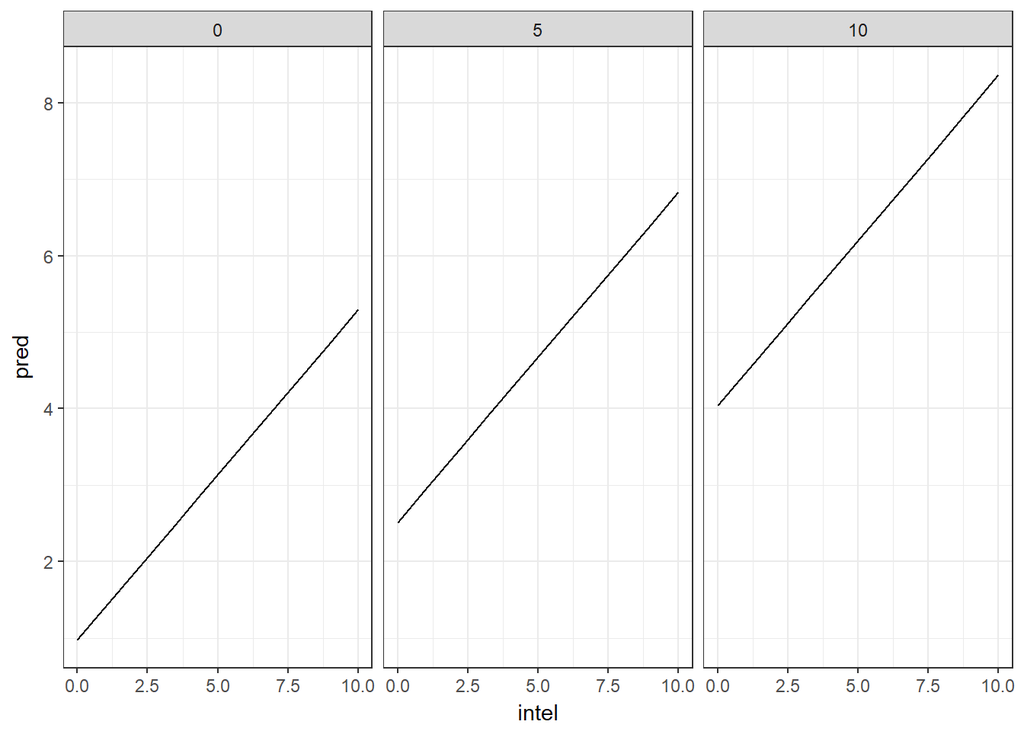

```r
model_intel_amb_aug <- speed_dating %>%
  data_grid(intel = seq_range(intel, 10),
            amb = seq_range(amb, 3)) %>%
  add_predictions(model_intel_amb)

model_intel_amb_aug %>%
  ggplot(aes(x = intel, y = pred)) +
  geom_line() +
  facet_grid(. ~ amb)
```

## Segunda pergunta

- Quanto mais uma pessoa se acha divertida e atraente, maior será a chance de achar que a outra pessoa irá querer se encontrar?

Agora queremos saber se a auto-estima de uma pessoa provoca uma tendência para que ela pense que a segunda irá desejar um segundo encontro. Neste caso, iremos caracterizar a auto-estima como o quanto ela se acha divertida e atraente. Talvez fique evidente que pessoas que se vejam de forma mais positiva do que outras possam agradar mais os pares em potencial. Realizamos a filtragem dos dados para depois criarmos um modelo de regressão linear que possa mostrar o quanto que as variáveis escolhidas influenciam na chance de acontecer o encontro.

```r
p2_data <- speed_dating %>%
  select(prob,attr3_s,fun3_s)
```

Observar a correlação entre as variáveis pode auxiliar o entendimento.

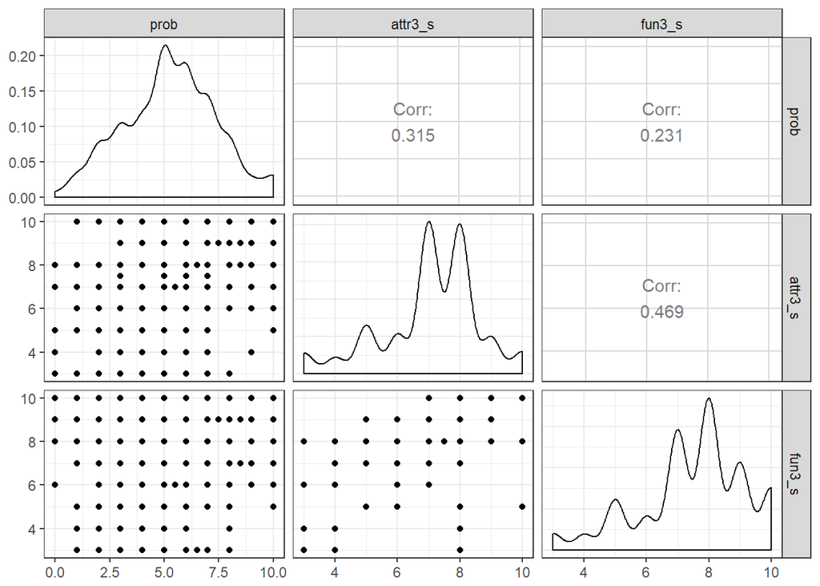

```r
p2_data %>%
  ggpairs()
```

Como observado acima, nossas variáveis estão fracamente relacionadas, visto que a correlação entre as variáveis não é muito forte.  
Definiremos o nosso modelo de regressão, com a variável que desejamos explicar como sendo a probabilidade do indivíduo achar que a outra pessoa querer um próximo encontro. As variáveis do modelo que serão explicativas ou independentes serão os valores que indicam quão a pessoa se acha atraente e divertida.

```r
model_attr_fun <- lm(prob ~ attr3_s + fun3_s, data = p2_data)
tidy(model_attr_fun, conf.int = TRUE)
```

```
##          term  estimate  std.error statistic      p.value   conf.low
## 1 (Intercept) 1.7438064 0.26230860  6.647919 4.051202e-11 1.22930640
## 2     attr3_s 0.3578545 0.03586940  9.976595 8.644236e-23 0.28749920
## 3      fun3_s 0.1328352 0.03298672  4.026929 5.912400e-05 0.06813403
##   conf.high
## 1 2.2583065
## 2 0.4282099
## 3 0.1975363
```

De acordo com a tabela, podemos analisar brevemente os resultados do modelo.  
A coluna **estimate** vai nos falar sobre a magnitude dos coeficientes. Temos que as variáveis independentes influenciam pouco na probabilidade do novo encontro. A atraência tem como coeficiente 0.35, enquanto a diversão apresenta um valor de 0.13. Isso pode ter ligação com a correlação entre as variáveis, que apresentou um valor baixo. Ou seja, nossas variáveis não serão muito influentes na probabilidade de um novo encontro. O **p-valor** irá nos mostrar o quanto as variáveis independentes do modelo são significantes para nossa variável dependente. O p-valor das duas é um valor muito pequeno, algo próximo de zero - o que nos mostra que elas são significativas e representam bem o modelo gerado. Elas também são relevantes para o modelo, visto que os intervalos de confiança não interceptam o zero (o que nos diria que há pouca relevância) e o p-valor está dentro dos intervalos, em cada uma das variáveis.  
Vemos também que quando os coeficientes das variáveis independentes forem zero, o modelo indicará que a probabilidade de um novo encontro será algo em torno de 1.74. Então podemos utilizar nosso modelo para representar a influencia das variáveis sobre a probabilidade de um novo encontro. Para observar o quando dos dados são explicados pelas duas variáveis independentes, podemos analisar o R quadrado.

```r
glance(model_attr_fun, conf.int = TRUE)
```

```
##   r.squared adj.r.squared   sigma statistic      p.value df    logLik
## 1 0.1083866     0.1072851 2.00865  98.40465 4.655503e-41  3 -3431.301
##        AIC      BIC deviance df.residual
## 1 6870.603 6892.168 6532.136        1619
```

Temos que as variáveis explicam muito pouco dos dados, revelando um valor estimado em 10%. Novamente nos remete ao baixo nível de correlação dos dados.

### Visualização do modelo

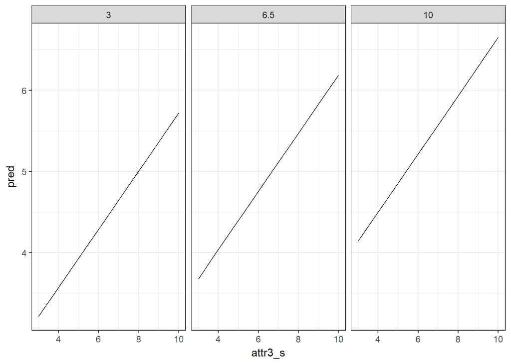

```r
model_attr_fun_aug <- speed_dating %>%
  data_grid(attr3_s = seq_range(attr3_s, 10),
            fun3_s = seq_range(fun3_s, 3)) %>%
  add_predictions(model_attr_fun)

model_attr_fun_aug %>%
  ggplot(aes(x = attr3_s, y = pred)) +
  geom_line() +
  facet_grid(. ~ fun3_s)
```

Pelo que o gráfico descreve acima, temos que cada grid representa o quanto o coeficiente da diversão própria aumenta. Mas vemos que essa variável exerce uma influencia muito pouca na probabilidade da pessoa achar que um novo encontro acontecerá, uma vez que o eixo y representa a predição dessa segunda variável e ela aumentou muito pouco ao longo deste eixo a medida que variável de diversão aumentou. Isso explica-se pelo fato do coeficiente para diversão ser muito pequeno, como foi visto anteriormente. Vemos também que o eixo x, que representa a atraência própria gera um peso um pouco maior na predição da variável independente, vista no eixo y. Isso é mais facilmente visto, pois só temos que observar a inclinação da reta, que terá relação com o coeficiente da atraência, visto anteriormente.  
Então verifica-se que o quanto a pessoa se acha mais atraente e divertida irá exercer pouca influência na probabilidade dela achar que um novo encontro acontecerá. Talvez essas variáveis não representem bem a auto-estima das pessoas. Ou também a auto-estima não tem nenhuma ligação com a chance dela considerar que a outra pessoa deseja um novo encontro.